# Tugas Pertemuan 6&7

Ibnu Yazid M0401241072

2026-09-30

```r
library(tsibble)
library(tseries)
```

```r
library(forecast)
library(ggplot2)
library(TSA)
library(rio)
```

### Data

```r
data <- import("C:/Users/Hype/OneDrive/文档/Semester 5/MPDW/MPDW/Pertemuan 1/MPDW Cabai merah.csv")
head(data)
```

```
##     Komoditas    Tanggal Harga
## 1 Cabai Merah 04/01/2021 57.50
## 2 Cabai Merah 05/01/2021 57.35
## 3 Cabai Merah 06/01/2021 56.35
## 4 Cabai Merah 07/01/2021 55.90
## 5 Cabai Merah 08/01/2021 54.90
## 6 Cabai Merah 11/01/2021 52.85
```

```r
data_100 <- data[1:100, ]
data_ts <- ts(data_100$Harga)
```

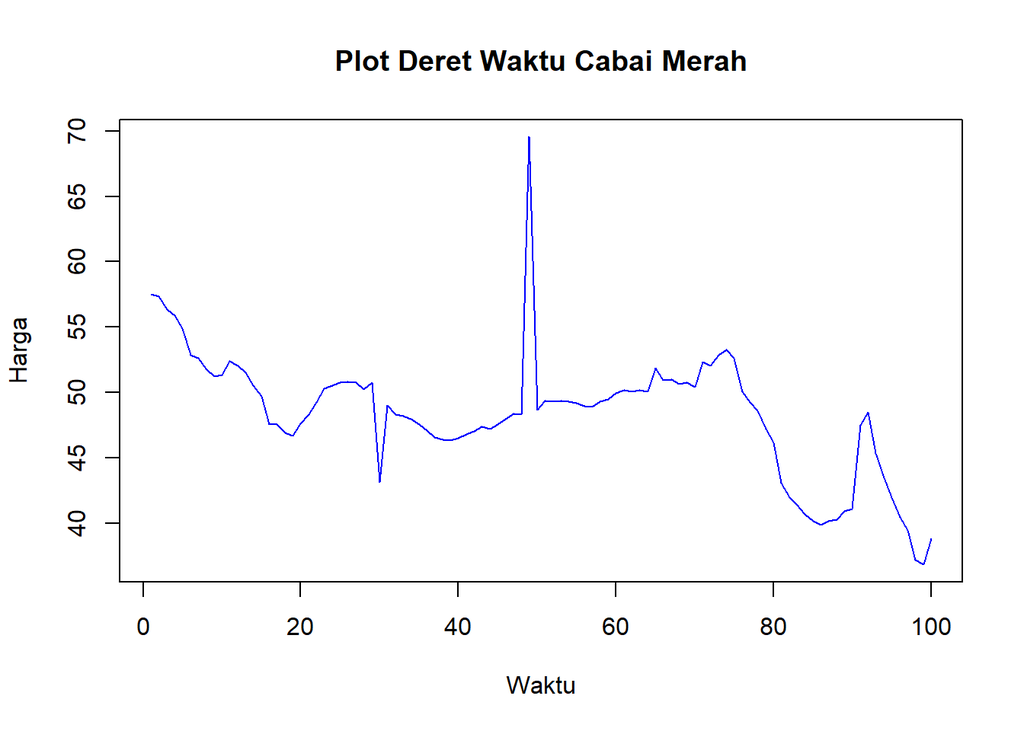

```r
plot.ts(data_ts, main = "Plot Deret Waktu Cabai Merah", ylab = "Harga", xlab = "Waktu", col = "blue")
```

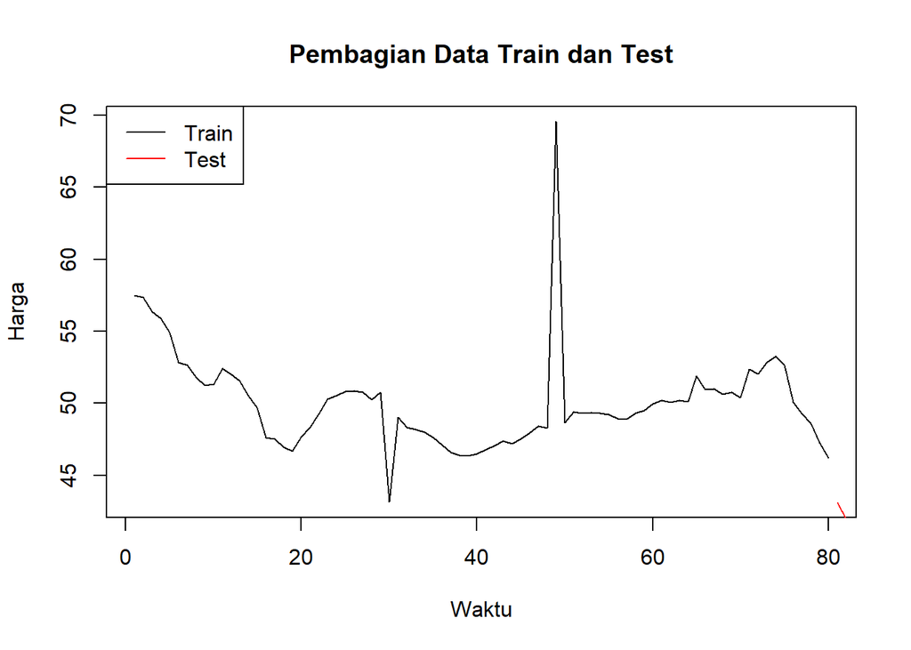

```r
n <- length(data_ts)
n_train <- round(0.8 * n)

train <- ts(data_ts[1:n_train])
test <- ts(data_ts[(n_train + 1):n], start = n_train + 1)

plot.ts(train, col = "black", main = "Pembagian Data Train dan Test", ylab = "Harga", xlab = "Waktu")
lines(test, col = "red")
legend("topleft", legend = c("Train", "Test"), col = c("black", "red"), lty = 1)
```

### Uji ADF

```r
adf.test(train)
```

```
##
##  Augmented Dickey-Fuller Test
##
## data:  train
## Dickey-Fuller = -3.3341, Lag order = 4, p-value = 0.07219
## alternative hypothesis: stationary
```

Karena p-value (0.07219) > 0.05, maka gagal tolak H0. Artinya data train tidak stasioner.

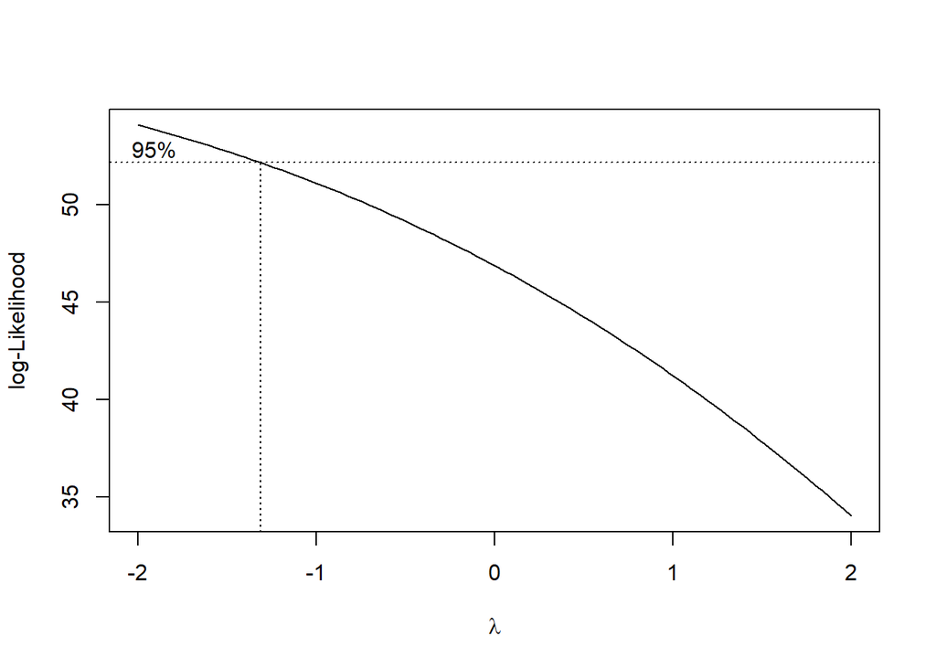

```r
library(MASS)
index <- seq_along(train)
bc <- boxcox(train ~ index)
```

```r
lambda <- bc$x[which.max(bc$y)]
lambda
```

```
## [1] -2
```

### Differencing

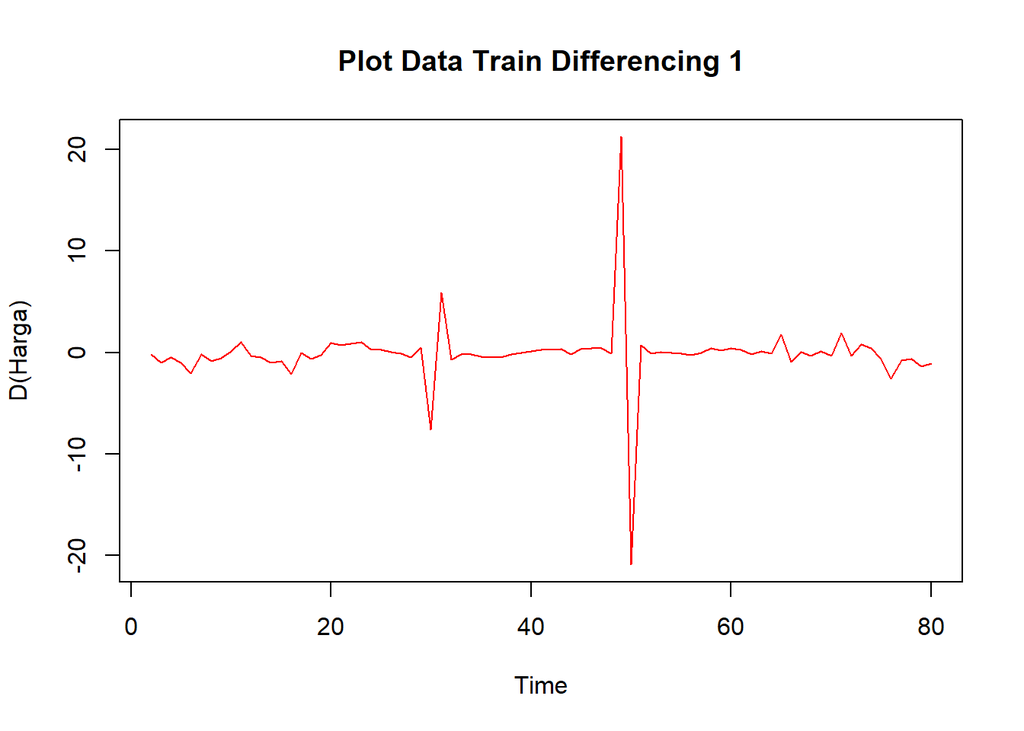

```r
train_diff <- diff(train)

plot.ts(train_diff, main = "Plot Data Train Differencing 1", ylab = "D(Harga)", col = "red")
```

```r
adf.test(train_diff)
```

```
##
##  Augmented Dickey-Fuller Test
##
## data:  train_diff
## Dickey-Fuller = -5.0272, Lag order = 4, p-value = 0.01
## alternative hypothesis: stationary
```

Setelah dilakukan differencing (d=1), uji ADF p-value nya < 0.05 (0.01). Data sudah stasioner pada d=1.

### Pemilihan model terbaik

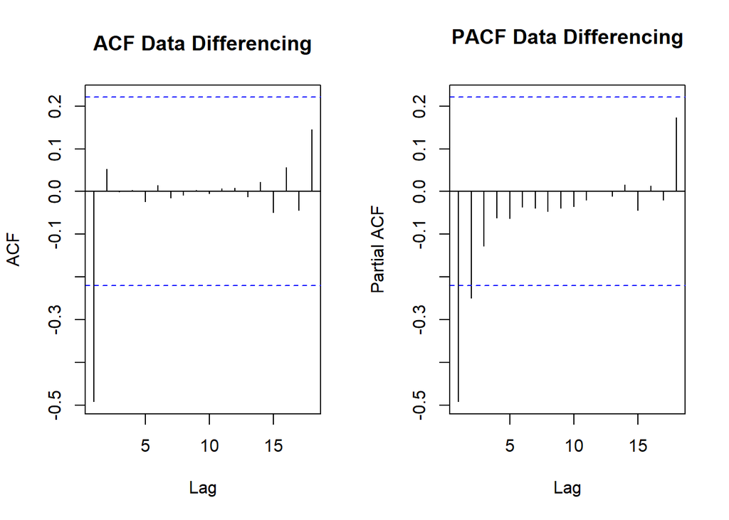

```r
par(mfrow = c(1, 2))
acf(train_diff, main = "ACF Data Differencing")
pacf(train_diff, main = "PACF Data Differencing")
```

```r
par(mfrow = c(1, 1))

eacf(train_diff)
```

```
## AR/MA
##   0 1 2 3 4 5 6 7 8 9 10 11 12 13
## 0 x o o o o o o o o o o  o  o  o
## 1 x o o o o o o o o o o  o  o  o
## 2 x o o o o o o o o o o  o  o  o
## 3 x o o o o o o o o o o  o  o  o
## 4 x x o o o o o o o o o  o  o  o
## 5 x x o o o o o o o o o  o  o  o
## 6 x o x o o o o o o o o  o  o  o
## 7 x o x o o o o o o o o  o  o  o
```

ACF: Signifikan/keluar garis batas biru pada lag 1. PACF: Signifikan/keluar garis batas biru pada lag 1 dan lag 2.

```r
model1 <- Arima(train, order = c(0, 1, 1))
model2 <- Arima(train, order = c(1, 1, 0))
model3 <- Arima(train, order = c(2, 1, 0))
model4 <- Arima(train, order = c(1, 1, 1))
model5 <- Arima(train, order = c(2, 1, 1))

model_auto <- auto.arima(train)

AIC(model1, model2, model3, model4, model5, model_auto)
```

```
##            df      AIC
## model1      2 402.3806
## model2      2 409.2171
## model3      3 406.4086
## model4      3 404.3039
## model5      4 405.9810
## model_auto  4 408.2740
```

Berdasarkan tabel perbandingan AIC yang baru, model1 [ARIMA(0,1,1)] memiliki nilai AIC terkecil yaitu 402.3806.

```r
library(lmtest)
summary(model1)
```

```
## Series: train
## ARIMA(0,1,1)
##
## Coefficients:
##           ma1
##       -0.6428
## s.e.   0.0966
##
## sigma^2 = 9.124:  log likelihood = -199.19
## AIC=402.38   AICc=402.54   BIC=407.12
##
## Training set error measures:
##                      ME     RMSE      MAE        MPE     MAPE     MASE
## Training set -0.3235828 2.982605 1.445638 -0.8529476 2.784318 1.184704
##                     ACF1
## Training set -0.03414414
```

```r
coeftest(model1)
```

```
##
## z test of coefficients:
##
##      Estimate Std. Error z value  Pr(>|z|)
## ma1 -0.642785   0.096638 -6.6515 2.902e-11 ***
## ---
## Signif. codes:  0 '***' 0.001 '**' 0.01 '*' 0.05 '.' 0.1 ' ' 1
```

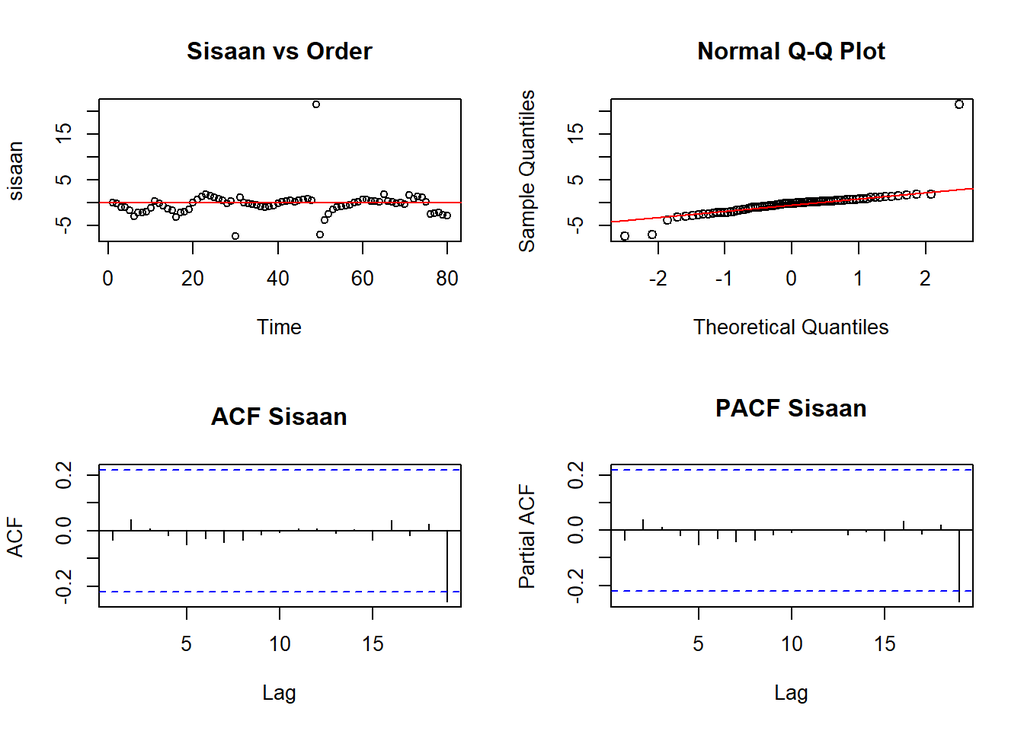

```r
sisaan <- residuals(model1)

par(mfrow = c(2, 2))
plot(sisaan, type = "p", main = "Sisaan vs Order")
abline(h = 0, col = "red")
qqnorm(sisaan)
qqline(sisaan, col = "red")
acf(sisaan, main = "ACF Sisaan")
pacf(sisaan, main = "PACF Sisaan")
```

```r
par(mfrow = c(1, 1))
```

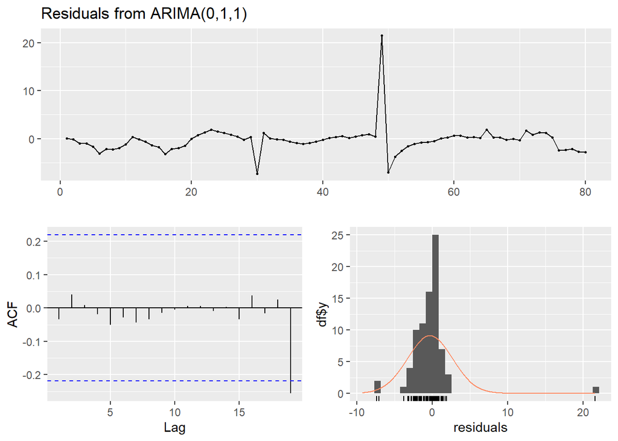

```
##
##  Ljung-Box test
##
## data:  Residuals from ARIMA(0,1,1)
## Q* = 0.85591, df = 9, p-value = 0.9997
##
## Model df: 1.   Total lags used: 10
```

```r
checkresiduals(model1)
```

```r
shapiro.test(sisaan)
```

```
##
##  Shapiro-Wilk normality test
##
## data:  sisaan
## W = 0.56283, p-value = 4.566e-14
```

Hasil uji Ljung-Box menunjukkan p-value sebesar 0,9997 > 0.05, sehingga keputusan tak tolak H0 yang mengindikasikan bahwa sisaan model ARIMA(0,1,1) bersifat bebas dari autokorelasi. Sementara itu, hasil uji Shapiro-Wilk menghasilkan p-value sebesar 4,566 x 10^-14 < 0.05, yang menunjukkan keputusan tolak H0 sehingga sisaan belum memenuhi asumsi berdistribusi normal.

### Pengujian Data Uji

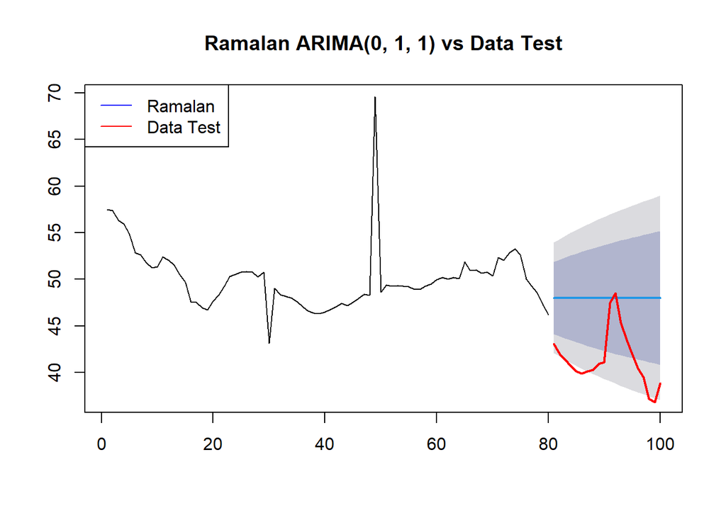

```r
h_test <- length(test)
ramalan <- forecast(model1, h = h_test)

plot(ramalan, main = "Ramalan ARIMA(0, 1, 1) vs Data Test")
lines(test, col = "red", lwd = 2)
legend("topleft", legend = c("Ramalan", "Data Test"), col = c("blue", "red"), lty = 1)
```

```r
accuracy(ramalan, test)
```

```
##                      ME     RMSE      MAE         MPE      MAPE     MASE
## Training set -0.3235828 2.982605 1.445638  -0.8529476  2.784318 1.184704
## Test set     -6.5406112 7.153511 6.589300 -16.3102565 16.410646 5.399945
##                     ACF1 Theil's U
## Training set -0.03414414        NA
## Test set      0.75350711  3.865401
```